# Celestial Mechanics Homework 3

## Giacomo Menegatti

2122852

```python
import matplotlib.pyplot as plt
from scipy.integrate import solve_ivp
import numpy as np
```

# Finding the central force of a particular orbit

The equation describing the curve is $r(\theta) = R + a \cos (k\theta + \phi)$, with $R>0$ radius of the perturbed circumference, $a$ the amplitude of the perturbation ($|a|<R$ to avoid reaching the origin), $k$ number of oscillations done in an orbit $\phi$ initial phase. If $k \in \mathbb{Z}$, the orbits are periodic.

To use Binet's equation the reciprocal of the radius is found as $u=\frac{1}{r}=\frac{1}{R+a\cos(k\theta+\phi)}$ and deriving twice gives $$\frac{d^2u}{d\theta^2}= \frac{k^2 a\cos (k\theta + \phi)}{(R+a\cos(k\theta+\phi))^2}+ \frac{2k^2a^2\sin^2(k\theta+\phi)}{(R+a\cos(k\theta+\phi))^3}$$ Now to have a central force this has to be rewritten as a function of $r$ by using $a\cos(k\theta +\phi) = r-R$ to eliminate $\cos$ and $\sin^2$. Substituting this gives the result $$\frac{d^2u}{d\theta^2} = \frac{k^2(r-R)}{r^2}+ \frac{2k^2(a^2-k^2(r-R)^2)}{r^3}$$

Now Binet's method states that for a central force the equation of motion $\ddot r - \frac{h^2}{r^3}+f(r)=0$ gives $\frac{d^2u}{d\theta^2}+u=\frac{1}{h^2u^2}f(\frac{1}{u})$. By using the previous solution and grouping the terms together, the result is $$f(r)= \frac{h^2-h^2k^2}{r^3}+3\frac{h^2k^2R}{r^4}+2\frac{k^2h^2(a^2-R^2)}{r^5}$$

Any force of the type $f(r)=\frac{A}{r^3}+\frac{B}{r^4}+\frac{C}{r^5}$ can give rise to this kind of orbits if, after choosing $h$, a tuple of values $R$, $k$, $a$ can be found to solve the system with the conditions $R>|a|>0$ and specific intial condotions are chosen.

In the following cell is reported a solution of the ODE after fixing R,a,k

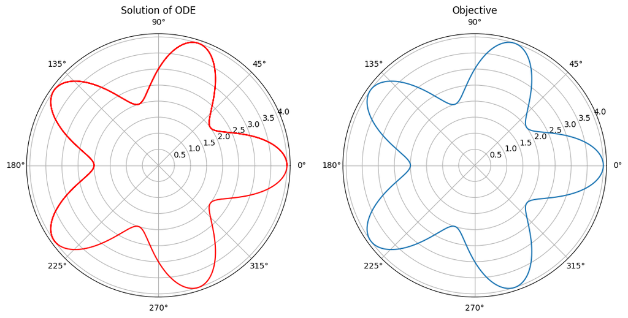

```python
def f(r, h, k, a, R):
  ''' Defining the central force '''
  # I'm not considering the term h^2/r^3 that cancels out in the equation of motion
  return -h**2*k**2/r**3 + 3*h**2*k**2*R/r**4 + 2*h**2*k**2*(a**2-R**2)/r**5



R, a, k = 3, 1, 5
r, dr, theta, dtheta = R+a, 0.0, 0.0, 0.5

h = r**2*dtheta

y0 = np.array([r,dr,theta])

def ode(t, y, h, k, a, R, f):
  ''' Defining the ODE associated to the system'''
  r, dr, theta = y[0], y[1], y[2]
  return np.array([dr, -f(r,h,k,a,R), h*r**-2])



Y = solve_ivp(ode, t_span=(0,12), y0=y0, t_eval=np.linspace(0,12,1000), args=(h,k,a,R, f), rtol=1e-12)

r, dr, theta = Y.y[0], Y.y[1], Y.y[2]

fig, AX = plt.subplots(1,2, figsize = (13,6), subplot_kw={'projection': 'polar'})
AX[0].set_title('Solution of ODE')
AX[0].plot(theta, r, 'r')

AX[1].set_title('Objective')
theta = np.linspace(0,2*np.pi, 1000)
AX[1].plot(theta, R+a*np.cos(k*theta))

plt.show()
```

## Orbit of a projectile

The projectile is launched east with a velocity of $5$ $km$ $s^{-1}$ at an angle of $45^\circ$ in the rotating Earth RF, so the velocity in an inertial RF is $\mathbf{v_I}= \mathbf{v} + \mathbf{\omega}\times \mathbf{R}$, with $\omega=\frac{2\pi}{23 h 56 min 4.1s}= 7.292 \cdot 10^{-5}$ $rad$ $s^{-1}$ agular speed of the Earth and the $R_E=6378.137$ $km$ equatorial radius. The velocity in the inertial RF is $v_I=5.339$ $km$ $s^{-1}$ with an angle of $41.468^\circ$ with the horizon.

Finally, the period of the orbit is given by $\frac{T^2}{a^3}=\frac{4\pi^2}{\mu}$ and the time from pericenter as $n(t-\tau)=\cos^{-1}[\frac{1}{e}(1-\frac{r}{a})]-e\sqrt{1-\frac{1}{e^2}(1-\frac{r}{a})^2}$. This gives the time of flight as $T-2t=1137$ $s$ and the angular distance covered in the Earth RF as $\phi-\omega\Delta t=29.09^\circ$

```python
v = 5 #Initail velocity
R = 6378.137  #Equatorial radius
T = 23*3600+56*60+4.100  #Sidereal rotation period
mu = 398600.4415  #Gravitational parameter
alpha = np.deg2rad(45)

omega = 2*np.pi/T
v = np.array([v*np.cos(alpha)+R*omega, v*np.sin(alpha)])  #velocity vector (horizontal and vertical components)
h = R*v[0]
C = 0.5*np.linalg.norm(v)**2-mu/R
e = (1+2*C*h**2/mu**2)**0.5
a = -mu/(2*C)
f = np.arccos(1/e*(a*(1-e**2)/R-1))

phi = 2*(np.pi-f)
print(f'The angular distance covered in the inertial RF is {np.rad2deg(phi)} deg')

T = (4*np.pi**2*a**3/mu)**0.5 #Period of the orbit
n = 2*np.pi/T
t = (np.arccos((1-R/a)/e) - e*(1-(1-R/a)**2/e**2)**0.5)/n
delta_t = T-2*t

print(f'The time of flight is {delta_t} s')
print(f'The angle covered in the Earth RF is {np.rad2deg(phi-omega*delta_t)} deg')
```

```
The angular distance covered in the inertial RF is 33.84449835570999 deg
The time of flight is 1137.1251066749837 s
The angle covered in the Earth RF is 29.09350532725621 deg
```

In the following plot of the trajectory followed I put the argument of pericenter to $0^\circ$

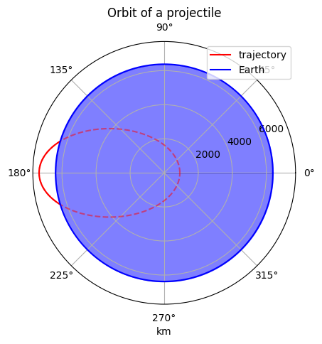

```python
theta = np.linspace(0, 2*np.pi, 1000)

r =lambda theta: a*(1-e**2)/(1+e*np.cos(theta))

ax = plt.subplot(projection='polar')
ax.plot(theta[r(theta)>R], r(theta)[r(theta)>R], color='r', label='trajectory')
ax.plot(theta, r(theta), color='r', linestyle='dashed', alpha=0.5)
ax.plot(theta, R*np.ones(shape=1000), color='blue', label='Earth')
ax.fill_between(theta, R, 0, color='blue', alpha=0.5)
ax.set_yticks(np.arange(2000,8000, 2000))
plt.legend(loc='best')
plt.title('Orbit of a projectile')
plt.show()
```

## Effect of the step-size on the integration of an ODE

This work and the following one is based on the points II and III of the paper *Stability of planetary systems: a numerical didactic approach* by Pakter and Levin.

In this first part the computational accuracy of the Euler's method for solving an ODE is analyzed

```python
import matplotlib.pyplot as plt
import numpy as np
from scipy.integrate import solve_ivp
from scipy.interpolate import interp1d
```

The initial conditions are $(x_1,y_1)=(-10,-0.5)m$, $(x_2,y_2)=(10,0.5)m$, $v_{x1}=1 \frac{m}{s}$, $v_{x2}=-1 \frac{m}{s}$, $v_{y1}=v_{y2}=0\frac{m}{s}$, with $M= 1.5\cdot 10^{10} kg$, $GM=1\frac{m^3}{s^2}$.

```python
def two_body_ODE(t ,y, GM):
  #Dividing y in positions and velocities
  r1, r2  = y[0:2], y[2:4]  #The first four variables are positions
  v1, v2 = y[4:6], y[6:8]  #The next four are velocities
  #Calculating the accelerations
  r_12 = r2-r1
  r3 = np.linalg.norm(r_12)**3
  #With concatenate I concatenate vectors side by side to get the state vector
  return np.array(np.concatenate((v1, v2, GM/r3*r_12, -GM/r3*r_12), axis=None))
```

```python
def Euler(f, y0, t_span, step=0.1, args=None):
  t0, tf = t_span[0], t_span[1]
  Y = [y0]
  T = [t0]
  t= t0

  while t < tf:

    y = np.array(Y[-1])
    y = y + step*f(t,y, *args)
    t  = t + step

    Y.append(y)
    T.append(t)

  return T, np.array(Y).T
```

```python
GM = 1.0
m = 1.5e10
#Initial positions and velocities
r1 = np.array([-10,-0.5])
r2 = np.array([10, 0.5])
v1 = np.array([1,0])
v2 = np.array([-1,0])

t0, tf = 0, 20

# Getting the modified state vector
y0 = np.concatenate((r1, r2, v1, v2), axis=None)


T1, Y1 = Euler(two_body_ODE, y0=y0, t_span=(t0, tf), step=0.5, args=(GM,))
T2, Y2 = Euler(two_body_ODE, y0=y0, t_span=(t0, tf), step=0.1, args=(GM,))
```

```python
def E(y):
  r1, r2  = y[0:2], y[2:4]
  v1, v2 = y[4:6], y[6:8]
  return 0.5*m*np.sum(v1**2, axis=0)+0.5*m*np.sum(v2**2, axis=0)-GM*m/np.linalg.norm(r1-r2, axis=0)
```

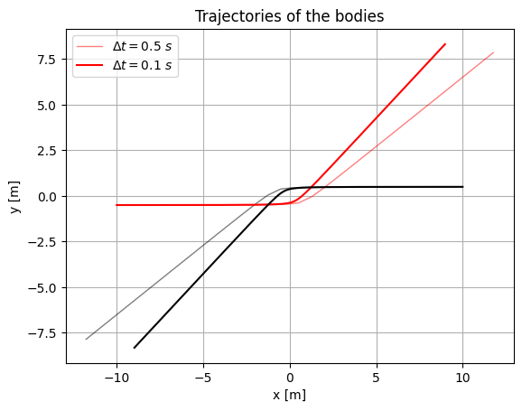

```python
E1 = E(Y1)
x1, y1, x2, y2, = Y1[0], Y1[1], Y1[2], Y1[3]

plt.plot(x1,y1,'r', lw=1, alpha=0.5, label =f'$\Delta t = 0.5$ $s$')
plt.plot(x2,y2,'k', lw=1, alpha=0.5)

E2 = E(Y2)
x1, y1, x2, y2, = Y2[0], Y2[1], Y2[2], Y2[3]
plt.plot(x1,y1,'r', label =f'$\Delta t = 0.1$ $s$')
plt.plot(x2,y2,'k')

plt.title('Trajectories of the bodies')
plt.xlabel('x [m]')
plt.ylabel('y [m]')
plt.legend()
plt.grid()
```

From the plot is clear how changing the integration step leads to different orbits. The thin lines are the solutions for $\Delta t=0.5s$, the others for $\Delta t=0.1s$.

In the following plot the energy of the system is calculated using $$E = \frac{Mv_1^2}{2}+\frac{Mv_2^2}{2}-\frac{GM^2}{r_{12}} $$

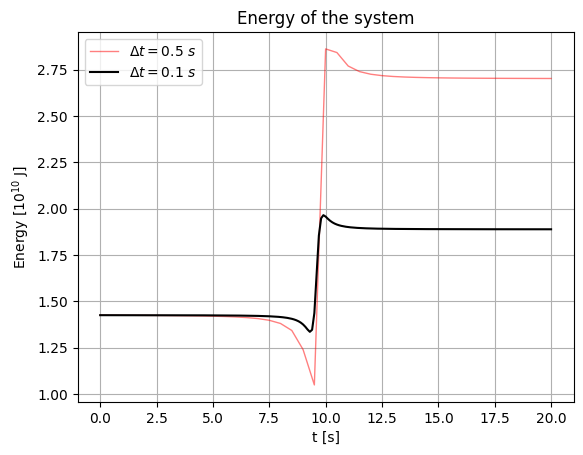

```python
energy_unit = 1e10

plt.title('Energy of the system')
plt.grid()
plt.plot(T1,E1/energy_unit, 'r', lw=1, alpha=0.5, label =f'$\Delta t = 0.5$ $s$')
plt.plot(T2,E2/energy_unit, 'k',label =f'$\Delta t = 0.1$ $s$')
plt.xlabel('t [s]')
plt.ylabel('Energy [$10^{10} $ J]')
plt.legend()
```

As expected, the energy is not stable and in both cases there is an increase after a sudden spike at $t=10$ $s$ that correspond to the close encounter, and the integration done with a smaller timestep is has a smaller energy error. In comparison to the paper, the spikes have a different form and the final difference is bigger.

## Investigating the relative energy error

```python
def energy_error(y):
  return np.abs(E(y[:,-1])/E(y[:,0])-1.0)
```

```python
steps = np.linspace(0.0001,1,100)
errors = []

for step in steps:
  _, y = Euler(two_body_ODE, y0=y0, t_span=(t0, tf), step=step, args=(GM,))
  errors.append(energy_error(y))
```

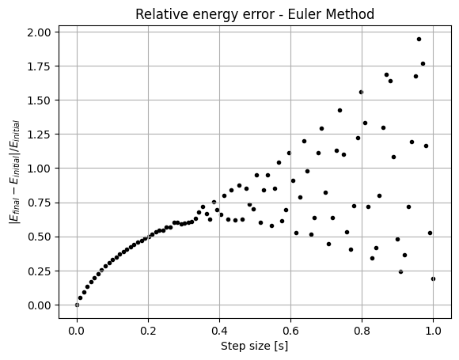

```python
errors = np.array(errors)
plt.xlabel('Step size [s]')
plt.ylabel('$|E_{final}-E_{initial}|/E_{initial}$')
plt.title('Relative energy error - Euler Method')
plt.scatter(steps[errors<5], errors[errors<5], color='k', marker = '.')
plt.grid()
```

```python
steps = np.linspace(0.0001,1,100)
errors = []

for step in steps:
  Y = solve_ivp(two_body_ODE, y0=y0, t_span=(t0, tf), max_step=step, atol=1, rtol=1, args=(GM,))
  errors.append(energy_error(Y.y))
```

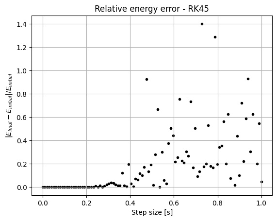

```python
errors = np.array(errors)
plt.xlabel('Step size [s]')
plt.ylabel('$|E_{final}-E_{initial}|/E_{initial}$')
plt.title('Relative energy error - RK45')
plt.scatter(steps[errors<5], errors[errors<5], color='k', marker = '.')
plt.grid()
```

```python
steps = np.logspace(-5.5, -0.5, 100)
errors = []

for step in steps:
  _, y = Euler(two_body_ODE, y0=y0, t_span=(t0, tf), step=step, args=(GM,))
  errors.append(energy_error(y))
```

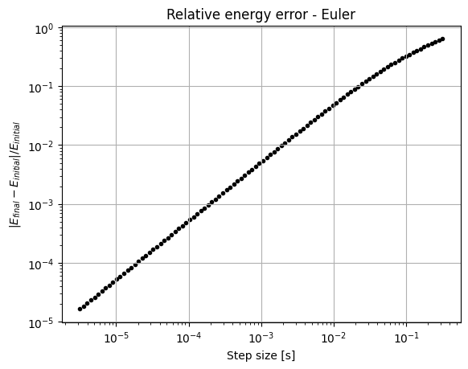

```python
errors = np.array(errors)
plt.xlabel('Step size [s]')
plt.xscale('log')
plt.ylabel('$|E_{final}-E_{initial}|/E_{initial}$')
plt.yscale('log')
plt.title('Relative energy error - Euler')
plt.grid()
plt.scatter(steps[errors<5], errors[errors<5], color='k', marker = '.')
```

In this logarithmic plot ot the energy error is visible only the nearly constant decrease of the error when snaller step sizes are used. The increase in the error below a certain value due to roundoff errors is not visible, and in general the errors are up to two orders of magnitude bigger than the ones in the paper.

The increase due to round-off errors when the step is too little is not shown. It is possible that such a patter will appear with smaller step sizes, but this would have require a much more intensive computation and/or an improvement of the methods, i.e using just-in-time compilation.

## Integration of a N-body system

In this part of the homework a 9 bodies system is simulated using the 4-th order Runge-Kutta. The system contains a central mass with mass close to the Sun ($M=2\cdot10^{30}$ $kg$) and 8 smaller masses with $m=10^{-4}M$ distributed from $2$ to $16$ a.u. and initial speed chosen to follow a circular orbit around the central mass.

```python
import matplotlib.pyplot as plt
import matplotlib.cm as cm
import numpy as np
from scipy.integrate import solve_ivp
```

```python
N = 8
M_sol = 2e30  #Solar mass
G = 6.6743e-11  #G in m^3 s^-2 kg^-1
au = 1.495978707e11 #Au in m
yr = 365.2422*24*3600 #Year in s
# G is now converted in AU^3 yr^-2 Msol^-1
G = G*au**-3*yr**2*M_sol
q = 1e-3  #softening factor
M = 1
t0, tf = 0, 2e4
```

The initial velocity for a circular motion with radius r has been calculated as $v = \sqrt{\frac{GM}{r}}$

```python
#Velocity of a circular orbit give the radius
v_circ = lambda r, GM:  (GM/r)**0.5
```

For the integration has been used the reltive form of the equation of motion centered on the principal mass using the Encke-Bettin formulation to improve numerical stability: $$ \mathbf{\ddot r_i}=-G\frac{M+m_i}{r^3_i}\mathbf{r}_i - \Sigma_{j\neq i}\frac{Gm_j}{\tilde r_{ij}^3}(\mathbf{r_i}+f_{ij}\mathbf{r_j}) $$ $$ q_{ij}=\frac{(\mathbf{r_i}-2\mathbf{r_j})\mathbf{r_i}}{r_j^2}$$ $$ f_{ij}=\frac{3q_{ij}+3q_{ij}^2+q_{ij}^3}{1+(1+q_{ij})^{1.5}} $$ To avoid the simulation collapsing in case of close encounters, Pakter and Levin used a smoothed of form of the potential: \begin{cases} V(r)= -\frac{(2d^3-2dr^2+r^3)Gm^2}{d^4} \quad r\leq d \\ V(r)= -\frac{Gm^2}{r}\quad r>d \end{cases} with $d=10^{-3}$ a.u. Because the scipy integrator cannot switch the form of the potential based on the distance, following the rebound documentation the following force was used $$ \mathbf F(r)=\frac{G m^2}{(r_{ij}^2+q^2)^{1.5}}\mathbf{r}_{ij}$$ that goes to zero for $r_{ij} \to 0$. Because the smaller masses are the most likely to undergo close encounters, this correction was done only for the distance between them ($\tilde r_{ij}$ in the equation above) with $q=10^{-3}$ a.u.

```python
def N_body(t,y,G,M,m):

  r_ = lambda y,i : y[[4*i, 4*i+1]]
  v_i = lambda y,i : y[[4*i+2, 4*i+3]]
  r_ij = lambda y,i,j,q: (np.linalg.norm(r_(y,i)-r_(y,j))**2+q**2)**0.5
  g = []

  for i in range(N):
    r_i = r_(y,i)
    g_i = -G*(M+m[i])*r_i/np.linalg.norm(r_i)**3
    for j in range(N):
      if i==j:
        continue
      else:
        #Perturbation part of the force
        #Encke-Bettin formulation
        r_j = r_(y,j)
        q_ij = np.dot(r_i-2*r_j, r_i)/np.dot(r_j,r_j)
        f_ij = (3*q_ij + 3*q_ij**2 +q_ij**3)/(1+(1+q_ij)**1.5)

        p_ij = -G*m[j]*(r_i+f_ij*r_j)/r_ij(y,i,j,q)**3
        g_i = g_i + p_ij

    g.append(g_i)

  dy = [[v_i(y,i), g[i]] for i in range(N)]
  return np.array(dy).flatten()
```

```python
m = 1e-4*np.ones(shape=N)
y0 = [[r,0,0,v_circ(r, G*M)] for r in np.linspace(2, 16, N)]
y0= np.array(y0).flatten()

Y1 = solve_ivp(N_body, t_span=(t0,tf), y0=y0, args=(G,M,m), rtol=1e-10, dense_output=True)
```

```python
T = np.linspace(t0,tf,int(1e5))
y = Y1.sol(T)
R = np.array([y[4*i : 4*i+2] for i in range(N)])
V = np.array([y[4*i+2 : 4*i+4] for i in range(N)])


r = np.array([np.linalg.norm(r_i, axis=0) for r_i in R])


K = 0.5*np.sum([m[i]*np.linalg.norm(V[i], axis=0)**2 for i in range(N)], axis=0)

#Potential energy between the masses
U_ij = np.sum([-G*m[i]*m[j]/np.linalg.norm(R[i]-R[j], axis=0) for i in range(N) for j in range(i)], axis=0)

#Potential energy between a mass and the central one
U_central = np.sum([-G*M*m[i]/r[i] for i in range(N)], axis=0)
E = K+U_central+U_ij

L = np.sum([m_i*np.cross(r_i, v_i, axis=0) for m_i, r_i, v_i in zip(m,R,V)], axis=0)
```

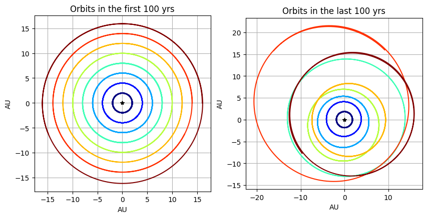

```python
colors = cm.jet(np.linspace(0,1,N))

fig, AX = plt.subplots(1,2, figsize=(10,5))
AX[0].set_aspect('equal')
AX[0].grid()
AX[0].set_xlabel('AU')
AX[0].set_ylabel('AU')
AX[0].plot(0,0,'k*')
AX[1].set_aspect('equal')
AX[1].grid()
AX[1].set_xlabel('AU')
AX[1].set_ylabel('AU')
AX[1].plot(0,0,'k*')
AX[0].set_title('Orbits in the first 100 yrs')
AX[1].set_title('Orbits in the last 100 yrs')


for R_i,c in zip(R,colors):
  AX[0].plot(R_i[0, :500], R_i[1, :500], color=c)

for R_i,c in zip(R,colors):
  AX[1].plot(R_i[0, -500:], R_i[1, -500:], color=c)
```

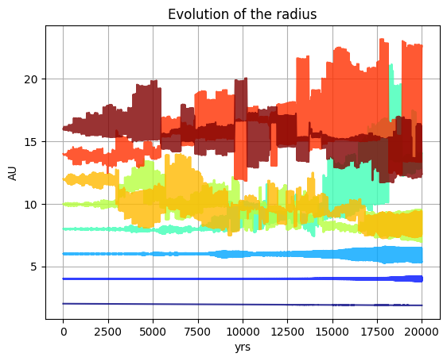

```python
for r_i, c in zip(r, colors):
  plt.plot(T, r_i, alpha =0.8, color=c)
plt.grid()
plt.title('Evolution of the radius')
plt.xlabel('yrs')
plt.ylabel('AU')
plt.show()
```

Compared with results from the paper, the evolution of the system shows several migrations. The instability of the system starts earlier and the final order of the planets is different. Also from the plot in the paper it appeard that the planets orbits are never intersecting (i.e., the distances are overimposed only in some points and not for long periods of time, as it happens in my simulation). This could happen because the potential used is different and/or the integrator is different, even if the same relative tolerance ($rtol=10^{-10}$) is used.

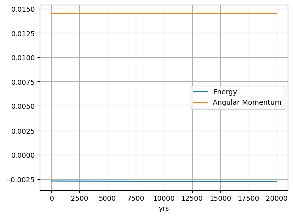

```
The relative error on the energy is 2.683530576332771%
The relative error on the angular momentum is -0.276056356559895%
```

```python
plt.plot(T, E, label='Energy')
plt.plot(T, L, label='Angular Momentum')
plt.xlabel('yrs')
plt.grid()
plt.legend()
plt.show()

E_err = E[-1]/E[0]-1
L_err = L[-1]/L[0]-1

print(f'The relative error on the energy is {100*E_err}%')
print(f'The relative error on the angular momentum is {100*L_err}%')
```

The energy and the angular momentum are nearly constant during the evolution (zooming in a lot some small spikes can be seen, corresponding to close encounters), and the relative error from beginning to end is pretty small.

## Integration of the planetary system with rebound

To judge the accuracy of the RK45 method I integrated the planetray system also using rebound. In this simulation all the equation are written with respect to the Center of Mass and were converted in the Sun centered RF at the end of the integration.

```python
import rebound
import numpy as np
import matplotlib.pyplot as plt
```

```python
N = 8
M_sol = 2e30  #Solar mass
G = 6.6743e-11  #G in m^3 s^-2 kg^-1
au = 1.495978707e11 #Au in m
yr = 365.2422*24*3600 #Year in s
# G is now converted in AU^3 yr^-2 Msol^-1
G = G*au**-3*yr**2*M_sol
q = 1e-3  #softening factor
M = 1
m = 1e-4
N_points = int(1e6)

v_circ = lambda r, GM:  (GM/r)**0.5
```

```python
sim = rebound.Simulation()
sim.G = G
sim.softening = q

sim.add(m=M, x=0, y=0, vx=0, vy=0)
for r in np.linspace(2, 16, N):
  sim.add(m=M*1e-4, x=r, y=0, vx=0, vy=v_circ(r,G*M))
#Move the system to the Center Of Mass RF
sim.move_to_com()


T = np.linspace(0,2e4,N_points)
y = []

for t in T:
    sim.integrate(t)
    y_t=[]
    for p in sim.particles:
        y_t.append([p.x, p.y, p.vx, p.vy])
    y.append(y_t)

Y = np.array(y)
```

```python
y_centered = [Y[:,i+1] - Y[:,0] for i in range(N)]
y = np.array(y_centered)

R = np.array([y[i,:,0:2] for i in range(N)])
V = np.array([y[i,:,2:4] for i in range(N)])


r = np.array([np.linalg.norm(r_i, axis=1) for r_i in R])


K = 0.5*np.sum([m*np.linalg.norm(V[i], axis=1)**2 for i in range(N)], axis=0)

#Potential energy between the masses
U_ij = np.sum([-G*m**2/np.linalg.norm(R[i]-R[j], axis=1) for i in range(N) for j in range(i)], axis=0)

#Potential energy between a mass and the central one
U_central = np.sum([-G*M*m/r[i] for i in range(N)], axis=0)
E = K+U_central+U_ij

L = np.sum([m*np.cross(r_i, v_i, axis=1) for r_i, v_i in zip(R,V)], axis=0)
```

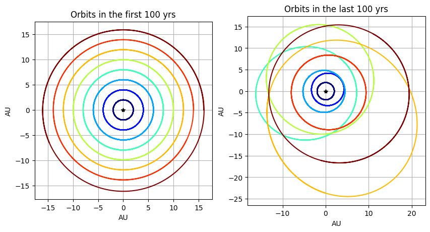

```python
import matplotlib.cm as cm

colors = cm.jet(np.linspace(0,1,N))

fig, AX = plt.subplots(1,2, figsize=(10,5))
AX[0].set_aspect('equal')
AX[0].grid()
AX[0].set_xlabel('AU')
AX[0].set_ylabel('AU')
AX[0].plot(0,0,'k*')
AX[1].set_aspect('equal')
AX[1].grid()
AX[1].set_xlabel('AU')
AX[1].set_ylabel('AU')
AX[1].plot(0,0,'k*')
AX[0].set_title('Orbits in the first 100 yrs')
AX[1].set_title('Orbits in the last 100 yrs')


for R_i,c in zip(R,colors):
  AX[0].plot(R_i[:5000,0], R_i[:5000,1], color=c)

for R_i,c in zip(R,colors):
  AX[1].plot(R_i[-5000:,0], R_i[-5000:,1], color=c)
```

Compared with the prevoius results, the final order of the planets has changed, and this simulation too predicts that some planets may share orbits for a long period of time.

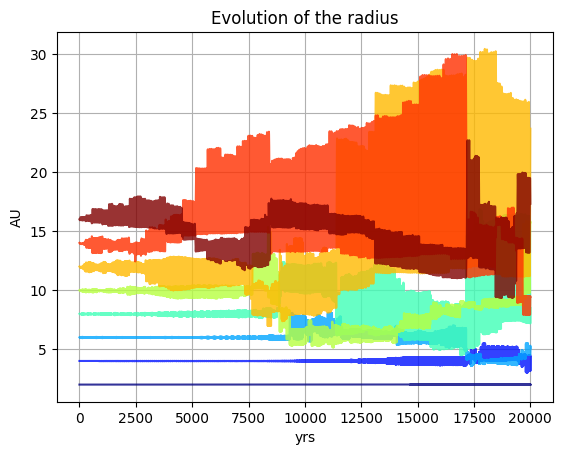

```python
for r_i, c in zip(r, colors):
  plt.plot(T, r_i, alpha =0.8, color=c)
plt.grid()
plt.title('Evolution of the radius')
plt.xlabel('yrs')
plt.ylabel('AU')
plt.show()
```

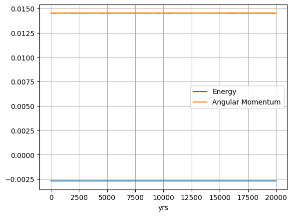

```
The relative error on the energy is 0.06808560720741319%
The relative error on the angular momentum is -0.09458097866582582%
```

```python
plt.plot(T, E, label='Energy')
plt.plot(T, L, label='Angular Momentum')
plt.xlabel('yrs')
plt.grid()
plt.legend()
plt.show()

E_err = E[-1]/E[0]-1
L_err = L[-1]/L[0]-1

print(f'The relative error on the energy is {100*E_err}%')
print(f'The relative error on the angular momentum is {100*L_err}%')
```